# MAA307_Homework_Part_2

## MAA307 - Convex optimization and optimal control - Homework Part 2

```
Auther 1 = 'Yubo Cai'
Email = 'yubo.cai@polytechnique.edu'

Auther 2 = 'Junyuang Wang'
Email = 'yubo.cai@polytechnique.edu'
```

```python
# pip install cma
```

```python
import cma, numpy as np
import matplotlib.pyplot as plt
from mpl_toolkits.mplot3d import Axes3D
from scipy.optimize import minimize_scalar, minimize
import scipy.optimize as scopt
```

### 2. Testing Gradient Descent, BFGS and Coordinate Descent

We consider the following class of objective functions defined in $\mathbb{R}^n$ $$ f_{\text {elli, cond }}(x)=\frac{1}{2} \sum_{i=1}^n(\text { cond })^{\frac{i-1}{n-1}} x_i^2 $$ for cond $>0$ a real value that will be taken in $\left\{1,10,10^2, \ldots, 10^6\right\}$. We also consider $R \in \mathbb{R}^{n \times n}$ a (random) rotation matrix non equal to the identity and define $$ f_{\text {rot-elli,cond }}(x)=f_{\text {elli,cond }}(x)(R x) . $$ Last we consider the Rosenbrock function $$ f_{\text {rosen }}(x)=\sum_{i=1}^{n-1}\left[100 \cdot\left(x_{i+1}-x_i^2\right)^2+\left(1-x_i\right)^2\right] . $$

### 2.1 Introduction

**Question a**

Compute the gradients and Hessian matrix of $f_{\text {elli,cond }}(x)$ and $f_{\text {rot-elli,cond }}(x)$. What are the condition numbers of the Hessian matrices of $f_{\text {elli, cond }}(x)$ and $f_{\text {rot-elli,cond }}(x)$ ?

| Answer to Question a |
| --- |

#### 1. $f_{\text {elli,cond }}(x)$

The gradient of this function with respect to each component $x_i$ is: $$ \frac{\partial f_{\text {elli, cond }}}{\partial x_i}=(\text { cond })^{\frac{i-1}{n-1}} x_i $$

So, the gradient vector is: $$ \nabla f_{\text {elli, cond }}(x)=\left[(\text { cond })^{\frac{0}{n-1}} x_1,(\text { cond })^{\frac{1}{n-1}} x_2, \ldots,(\text { cond })^{\frac{n-1}{n-1}} x_n\right] $$

Then we can compute the Hessain matrix: $$ H\left(f_{\text {elli, cond }}\right)=\operatorname{diag}\left[(\text { cond })^{\frac{0}{n-1}},(\text { cond })^{\frac{1}{n-1}}, \ldots,(\text { cond })^{\frac{n-1}{n-1}}\right] $$ Since condition number is large than 0, which means $H\left(f_{\text {elli, cond }}\right)$ is positive-definite symmetric matrix, so the condition number of $H\left(f_{\text {elli, cond }}\right)$ is the ratio of the largest eigenvalue to the smallest eigenvalue.

Since we know that $\text{cond} \geq 1$ (which is taken value from $\{1, 10, 10^{2}, ..., 10^{6}\}$), we have: $$ \operatorname{cond}\left(H\left(f_{\text {elli, cond }}\right)\right)=\frac{(\text { cond })^{\frac{n-1}{n-1}}}{(\text { cond })^{\frac{0}{n-1}}}=\text { cond } $$

#### 2. $f_{\text {rot-elli,cond }}(x)$

The gradient of $f_{\text {rot-elli, cond }}$ can be obtained using the chain rule: $$ \nabla f_{\text {rot-elli, cond }}(x)=R^T \nabla f_{\text {elli, cond }}(R x) $$

Hessian Matrix of $f_{\text {rot-elli, cond }}(x)$ The Hessian matrix of $f_{\text {rot-elli, cond }}$ is: $$ H\left(f_{\text {rot-elli, cond }}\right)=R^T H\left(f_{\text {elli, cond }}(R x)\right) R $$ First, we try to prove that the Hessian matrix after rotation has the same eigenvalues. Since $R$ is a rotation matrix, then we know that $R$ is orthogonal matrix, which means $R^T =R^{-1}$. Assume we have a vector $v$ that $Av=av$ (from definition of eigenvector) where A is a matrix $$ Q^{-1}AQ(Q^{-1}v)=Q^{-1}Av=aQ^{-1}v \quad \text { where } a \text { is the eigenvalue (constant) of } A $$ Then we know that $Q^{-1}AQ$ has the same eigenvalues as $A$. Therefore, the condition number of $H\left(f_{\text {rot-elli, cond }}\right)$ should be the same as that of $H\left(f_{\text {elli, cond }}\right)$, which is $\boxed{\text{cond}}$.

**Question b**

Show that $f_{\text {elli,cond }}(x)$ and $f_{\text {rot-elli,cond }}(x)$ are $\mu$-strongly convex and $L$-smooth and identify the largest (respectively smallest) $\mu$ (respectively $L$ ) depending on the parameter cond.

| Answer to Question b |
| --- |

We first recall the definition of $\mu$-strongly convex and $L$-smooth, We call a function is $L$-smooth if $$ f(x) \leqslant f\left(x_0\right)+<\nabla f\left(x_0\right), x-x_0>+\frac{L}{2}\left\|x-x_0\right\|^2 \quad \forall x $$ and $\mu$-strongly convex if $$ f\left(x_0\right)+<\nabla f\left(x_0\right), x-x_0>+\frac{\mu}{2}\left\|x-x_0\right\|^2 \leqslant f(x) \quad \forall x $$

#### 1. $f_{\text {elli,cond }}(x)$

Since we know $H\left(f_{\text {elli, cond }}\right)=\operatorname{diag}\left[(\text { cond })^{\frac{0}{n-1}},(\text { cond })^{\frac{1}{n-1}}, \ldots,(\text { cond })^{\frac{n-1}{n-1}}\right]$ and $f_{\text {elli, cond}}(x)$ is L-smooth for values of $H\left(f_{\text {elli, cond }}\right)\preceq L Id$, which we can deduce that $\text{cond} \leq L$. Therefore, we have the smallest $L$ is $\boxed{\text{cond}=1}$.

#### 2. $f_{\text {rot-elli,cond }}(x)$

**Question c**

Display the sublevel sets of the Rosenbrock function in dimension 2. Is the function convex, quasi-convex?

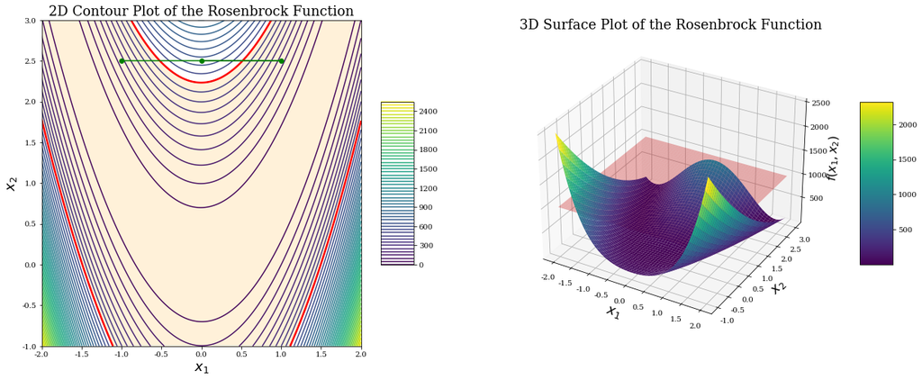

```python
# Define the Rosenbrock function
def rosenbrock(x, y):
    return 100 * (y - x**2)**2 + (1 - x)**2


# Create a grid of points
x = np.linspace(-2, 2, 600)
y = np.linspace(-1, 3, 600)
X, Y = np.meshgrid(x, y)
Z = rosenbrock(X, Y)

# Create a figure with two subplots
fig = plt.figure(figsize=(21, 8))

# 2D contour plot
ax1 = fig.add_subplot(121)
contour = ax1.contour(X, Y, Z, 50, cmap='viridis')  # Colored contour lines
r = 500  # Level set value
# Sublevel set contour, with red line
sublevel_contour = ax1.contour(
    X, Y, Z, levels=[r], colors='red', linewidths=2.5)
# Sublevel set shaded area with orange color
ax1.contourf(X, Y, Z, levels=[0, r], colors='orange', alpha=0.15)
fig.colorbar(contour, ax=ax1, shrink=0.5, aspect=5)
ax1.set_xlabel(r'$x_1$', size=18)
ax1.set_ylabel(r'$x_2$', size=18)
ax1.set_title('2D Contour Plot of the Rosenbrock Function',
              fontfamily='serif', size=18)

# Mark and connect points (-1.0, 2.5) and (1.0, 2.5)
points_x = [-1.0, 1.0, 0]
points_y = [2.5, 2.5, 2.5]
ax1.plot(points_x, points_y, 'go-')  # Green color, circle markers, solid line

# 3D surface plot
ax2 = fig.add_subplot(122, projection='3d')
surf = ax2.plot_surface(X, Y, Z, cmap='viridis', edgecolor='none')
r = 1000  # Level set value
ax2.plot_surface(X, Y, np.full_like(Z, r), alpha=0.3,
                 color='red')  # Sublevel set plane
fig.colorbar(surf, ax=ax2, shrink=0.5, aspect=5, pad=0.1)
ax2.set_xlabel(r'$x_1$', size=18)
ax2.set_ylabel(r'$x_2$', size=18)
ax2.set_zlabel(r'$f(x_{1}, x_{2})$', size=16)
ax2.set_title('3D Surface Plot of the Rosenbrock Function',
              fontfamily='serif', size=18)

# Show the plots
plt.show()
```

| Answer to Question c |
| --- |

We have for 2D Rosenbrock function: $$ f_{\text {rosen }}(x)=100 \cdot\left(x_{2}-x_1^2\right)^2+\left(1-x_1\right)^2 $$ We plot the sublevel sets of the Rosenbrock function in dimension 2 as the above graph. In the 2D plot, we show the sublevel set $\text{lev}_{\gamma}f_{\text{rosen}}(x)$ with $\gamma=500$, which is the orange area. We can see that the orange area is not convex, so the Rosenbrock function is **not convex** (show in the green line). Also, we can see that the Rosenbrock function is **not quasi-convex**.

You will now consider three optimization algorithms. Gradient descent with fixed step-size that you will implement yourself, the quasi-Newton BFGS algorithm (you can use the implementation in scipy.optimize, see below) and the coordinate-descent algorithm defined as:

**Coordinate descent (CD)**:

| Given $f: \mathbb{R}^n \rightarrow \mathbb{R}$. Initialize $x_0 \in \mathbb{R}^n$ For $k=1,2, \ldots$, Define $x_{k+1}$ from $x_k$ by iteratively optimizing $f$ along each coordinate, namely, for each… |
| --- |

We choose the convention to call $k$ the iteration index. Remark that at each iteration, the algorithm performs $n$ 1-dimensional optimization procedures.

### 2.2 Invariance of coordinate descent

**Question a**

How many iterations are needed to minimize (2)? Does it depend on the parameter cond? Provide a small theoretical proof.

| Answer to Question a |
| --- |

Consider $f(x)=\frac{1}{2} \sum_{i=1}^n(\text { cond })^{\frac{i-1}{n-1}} x_i^2$ where $x=(x_1^{1}, x_1^{2},...,x_1^{n})$. Assume we have the initial point $x_0=(x_1^{1}, x_1^{2},...,x_1^{n})$. Then we try to compute $$ \begin{aligned} x_{2}^{1} &= \underset{y \in \mathbb{R}}{\arg \min } f\left(y, x_1^{2}, \ldots, x_1^n\right) \\ &= \underset{y \in \mathbb{R}}{\arg \min } \left(\frac{1}{2} \text{cond}^{0}(y)^{2} + \frac{1}{2} \sum_{i=2}^n \operatorname{cond} d^{\frac{i-1}{n-1}}\left(x_1^i\right)^2\right) \end{aligned} $$ Then we have $y=0$. We repeat the same procedure for $x_2^{2},...,x_k^{n}$. We can deduce that $x^{\prime}=(x_2^{1}, x_2^{2},...,x_2^{n})=(0,...,0)$ and $f(x^{\prime})=0$.

Note that $f(x)\geq 0$ for $x \in R^n$, therefore we prove that it reaches the minimum after one iteration.

Also, since after one iteration, we have $x^{\prime}=(x_2^{1}, x_2^{2},...,x_2^{n})=(0,...,0)$, we can deduce that it does not depend on the parameter cond.

**Question b**

We now want to study quantitatively the impact of rotating the search space on the performance of CD. Implement CD to minimize numerically (2) and (3). To perform the 1D-search in the coordinate descent, one can use the minimize_scalar function from scipy optimize implementing the Brent method.

```
from scipy.optimize import minimize_scalar
```

```python
# Define the elliptical function
def f_elli_cond(x, cond):
    n = len(x)
    return 0.5 * sum((cond ** ((i) / (n - 1))) * (x[i] ** 2) for i in range(n))


def f_rot_elli_cond(x, cond, R):
    # Apply rotation to the input vector x
    y = R(x)
    return f_elli_cond(y, cond)


def coordinate_descent(x0, cond, R, max_iter=10**7, tol=1e-10, rotate=False):
    x = x0.copy()
    num_iter = 0
    n = len(x)
    ftab = []
    x_tab = []
    for num_iter in range(max_iter):
        x_prev = x.copy()
        if rotate:
            ftab.append(f_rot_elli_cond(x, cond, R))
        else:
            ftab.append(f_elli_cond(x, cond))
        for i in range(n):
            # Define a one-dimensional function for the i-th coordinate
            def g(y):
                x_new = np.copy(x)
                x_new[i] = y
                if rotate:
                    return f_rot_elli_cond(x_new, cond, R)
                else:
                    return f_elli_cond(x_new, cond)

            # Minimize along the i-th coordinate
            res = minimize_scalar(g, method='brent')
            x[i] = res.x
            x_tab.append(x)

        # Check for convergence
        if np.linalg.norm(x - x_prev) < tol:
            break

    return x, num_iter, ftab, x_tab
```

```python
cond = 10  # Condition parameter
n = 10  # Dimension of the problem
# select random initial point from 0 to 2
x0 = np.random.uniform(0, 10, n)
print('Initial point:', x0)
R = cma.transformations.Rotation()

result_CD_elli = coordinate_descent(x0, cond, R)
print('Coordinate descent method (without rotation):', result_CD_elli[0])
print('Number of iterations:', result_CD_elli[1])
print('Value of the objective function (Minimized):',
      f_elli_cond(result_CD_elli[0], cond))
```

```
Initial point: [8.69327512 6.97777693 2.76093806 0.52264326 7.77763023 0.01319037
 8.57536227 6.52622986 3.75413246 7.83970563]
Coordinate descent method (without rotation): [0. 0. 0. 0. 0. 0. 0. 0. 0. 0.]
Number of iterations: 2
Value of the objective function (Minimized): 0.0
```

```python
result_CD_rot = coordinate_descent(x0, cond, R, rotate=True)
print('Coordinate descent method (with rotation):', result_CD_rot[0])
print('Number of iterations:', result_CD_rot[1])
print('Value of the objective function (Minimized):',
      f_rot_elli_cond(result_CD_rot[0], cond, lambda x: x))
```

```
Coordinate descent method (with rotation): [-3.41363318e-11 -4.55107152e-11  5.62656853e-11  2.69348172e-11
 -1.00000000e-11  4.08081374e-11  4.86877564e-11  3.22904600e-11
 -1.91367173e-11  0.00000000e+00]
Number of iterations: 37
Value of the objective function (Minimized): 1.8518178525159157e-20
```

The result of our numerical implementation proves the result from **Question 2.2 (a)**.

**Question c**

Display the number of iterations needed by $\mathrm{CD}$ to reach a function value which is smaller than $10^{-8}$ as a function of the parameter cond $\in\left\{1,10, \ldots, 10^5\right\}$ when minimizing (2) and (3) for $n=10$. Display on the same graph the results for (2) and (3). Describe the results that appear on the graph.

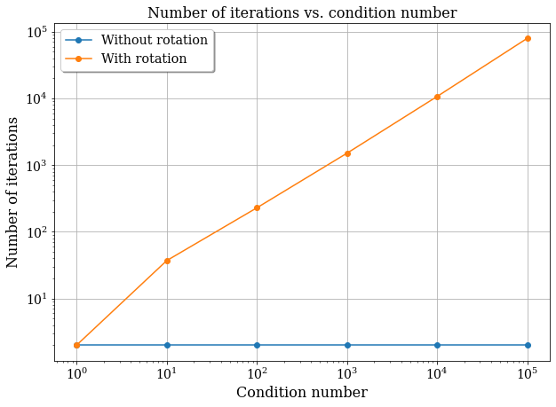

```python
conditon_set = [10 ** i for i in range(6)]
iterations_nonrot = []
iterations_rot = []

for cond in conditon_set:
    result_CD_elli = coordinate_descent(x0, cond, R)
    iterations_nonrot.append(result_CD_elli[1])
    result_CD_rot = coordinate_descent(x0, cond, R, rotate=True)
    iterations_rot.append(result_CD_rot[1])

# ploting of the graph
plt.figure(figsize=(10, 7))
plt.plot(conditon_set, iterations_nonrot, 'o-', label='Without rotation')
plt.plot(conditon_set, iterations_rot, 'o-', label='With rotation')
plt.xscale('log')
plt.yscale('log')
plt.xlabel('Condition number', size=16, fontfamily='serif')
plt.ylabel('Number of iterations', size=16, fontfamily='serif')
plt.title('Number of iterations vs. condition number', size=16, fontfamily='serif')
plt.legend(shadow=True, fontsize='x-large')
plt.tick_params(axis='x', labelsize=14)
plt.tick_params(axis='y', labelsize=14)
plt.grid(True)
plt.show()
```

```python
print('Number of iterations without rotation:', iterations_nonrot)
print('Number of iterations with rotation:', iterations_rot)
```

```
Number of iterations without rotation: [2, 2, 2, 2, 2, 2]
Number of iterations with rotation: [2, 37, 229, 1509, 10695, 79635]
```

| Answer to Question c |
| --- |

**Question d**

Is it surprising that CD needs more iterations on (3)? Do the results suggest that CD is rotational invariant?

| Answer to Question d |
| --- |

The results are not surprising since the result reflect the impact of rotation on the performance of Coordinate Descent (CD) . The rotation introduce dependencies on coordinates of the function $f_{\text {rot-elli,cond }}(x)$, which increase the complexity of the optmization algorithm and increase the number of iterations needed to reach the minimum. The results suggest that CD is not rotational invariant.

A rotationally invariant algorithm would show consistent performance regardless of the rotation of the search space. For example, the number of interations needed to reach the minimum should be the same for both (2) and (3) which is not the case from what we have observed. The increasing iterations implies that the algorithm is not rotationally invariant and affected by the rotation of the search space.

**Question e**

Find a theoretical explanation to your conclusion on the (non) rotational invariance of CD.

```python
# define the 2D function
def f_elli_cond_2D(x, y, cond):
    return 0.5 * (x ** 2 + cond * y ** 2)

def f_rot_elli_cond_2D(x, y, cond, R):
    # Apply rotation to the input vector x
    y = R([x, y])
    return f_elli_cond_2D(y[0], y[1], cond)

def coordinate_descent_2D(x0, cond, R, max_iter=10**7, tol=1e-10, rotate=False):
    x = x0.copy()
    num_iter = 0
    n = len(x)
    ftab = []
    x_tab = []
    for num_iter in range(max_iter):
        x_prev = x.copy()
        x_tab.append(x_prev)
        if rotate:
            ftab.append(f_rot_elli_cond_2D(x[0], x[1], cond, R))
        else:
            ftab.append(f_elli_cond_2D(x[0], x[1], cond))
        for i in range(n):
            # Define a one-dimensional function for the i-th coordinate
            def g(y):
                x_new = np.copy(x)
                x_new[i] = y
                if rotate:
                    return f_rot_elli_cond_2D(x_new[0], x_new[1], cond, R)
                else:
                    return f_elli_cond_2D(x_new[0], x_new[1], cond)

            # Minimize along the i-th coordinate
            res = minimize_scalar(g, method='brent')
            x[i] = res.x

        # Check for convergence
        if np.linalg.norm(x - x_prev) < tol:
            break

    return x, num_iter, ftab, x_tab
```

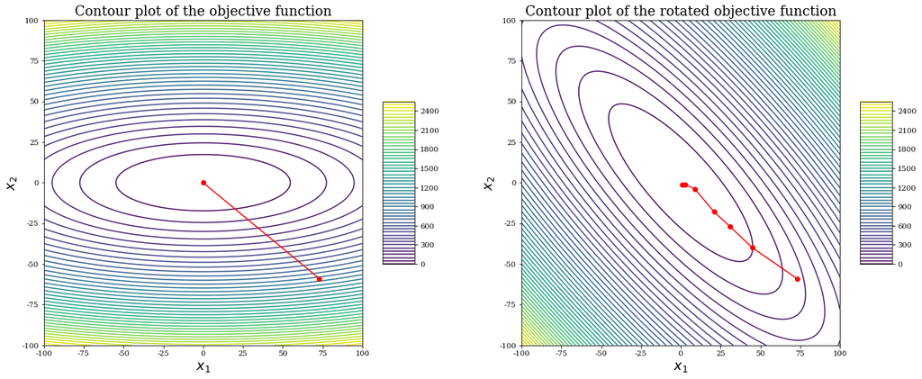

```python
# Parameters
n = 2
cond = 10
R = cma.transformations.Rotation()  # Generate a rotation matrix

# Initial point
x0 = np.array([73, -59])

x = np.linspace(-100, 100, 2000)
y = np.linspace(-100, 100, 2000)
X, Y = np.meshgrid(x, y)
Z = f_elli_cond_2D(X, Y, cond)
Z_rot = [[0 for i in range(2000)] for j in range(2000)]
for i in range(2000):
    for j in range(2000):
        Z_rot[i][j] = f_rot_elli_cond_2D(X[i][j], Y[i][j], cond, R)

# get the CD result
result_CD_elli = coordinate_descent_2D(x0, cond, R)[3]
result_CD_rot = coordinate_descent_2D(x0, cond, R, rotate=True)[3]

# plot the graph of
fig = plt.figure(figsize=(21, 8))
ax1 = fig.add_subplot(121)
ax1.contour(X, Y, Z, 50, cmap='viridis')
ax1.set_xlabel(r'$x_1$', size=18)
ax1.set_ylabel(r'$x_2$', size=18)
fig.colorbar(contour, ax=ax1, shrink=0.5, aspect=5)
ax1.set_title('Contour plot of the objective function',
              fontfamily='serif', size=18)
# plot the trajectory
x_tab = [x[0] for x in result_CD_elli]
y_tab = [x[1] for x in result_CD_elli]
ax1.plot(x_tab, y_tab, 'ro-')

ax2 = fig.add_subplot(122)
ax2.contour(X, Y, Z_rot, 50, cmap='viridis')
ax2.set_xlabel(r'$x_1$', size=18)
ax2.set_ylabel(r'$x_2$', size=18)
fig.colorbar(contour, ax=ax2, shrink=0.5, aspect=5)
ax2.set_title('Contour plot of the rotated objective function',
              fontfamily='serif', size=18)
# plot the trajectory
x_tab_rot = [x[0] for x in result_CD_rot]
y_tab_rot = [x[1] for x in result_CD_rot]
ax2.plot(x_tab_rot, y_tab_rot, 'ro-')

plt.show()
```

| Answer to Question e |
| --- |

For the function $f_{\text {elli,cond }}(x)$, which is an elliptical function, the level sets are elongated ellipses that are axis-aligned. CD efficiently moves towards the minimum because each coordinate-wise step can directly make progress towards the minimum along each axis. However, if we apply a rotation $R$ to the function, the level sets of the function to be rotated away from being aligned with the coordinate axes. In this rotated function, a step along one of the original coordinates does not align with the steepest descent direction of the rotated function. Consequently, each coordinate-wise step may not lead directly towards the minimum, which increases the number of iterations needed to reach the minimum. We can plot a 2D graph to illustrate the difference between the two functions.

### 2.3 Influence of cond on GD and BFGS.

**Question a**

Reproduce the graph shown in class 9 (slide 1 entitled "Sensibility of gradient descent wrt condition number"), showing the sensibility of gradient descent wrt condition number (realize that there is a difference of $1 / 2$ between the function used and the function (2)). Comment what you observe on the graph.

```python
def gradient_f_elli_cond(x, cond):
    n = len(x)
    return np.array([cond ** (i / (n - 1)) * x[i] for i in range(n)])

def gradient_descent_elli_cond(initial_x, cond, alpha, threshold=1e-10, max_iter=10000000):
    x = initial_x
    num_iter = 0

    for num_iter in range(max_iter):
        grad = gradient_f_elli_cond(x, cond)
        x_new = x - alpha * grad
        if np.linalg.norm(x_new - x) < threshold:
            break
        x = x_new

    return x, f_elli_cond(x, cond), num_iter + 1

def optimize_f_elli_cond_bfgs(initial_x, cond, threshold=1e-10, max_iter=10000000):
    """Optimize the elliptical function using BFGS.

    Parameters:
    - initial_x: Starting point for the optimization.
    - cond: Condition number.

    Returns:
    - The optimized value of x and the function value at that point.
    """
    result = minimize(fun=f_elli_cond, x0=initial_x, args=(cond), method='BFGS', jac=gradient_f_elli_cond, tol=threshold, options={'maxiter': max_iter})
    return result.x, result.fun, result.nit
```

```python
conditon_set = [10 ** i for i in range(6)]
n = 20  # Dimension of the problem
x0 = np.random.uniform(0, 10, n)
print('Initial point:', x0)
print('-' * 100)
result_GD = gradient_descent_elli_cond(x0, cond, alpha=1/cond)
result_BFGS = optimize_f_elli_cond_bfgs(x0, cond)
print('Gradient descent method, final x', result_GD[0])
print('Gradient descent method, final objective value', result_GD[1])
print('Number of iterations (GD):', result_GD[2])
print('-' * 100)
print('BFGS method, final x', result_BFGS[0])
print('BFGS method, final objective value', result_BFGS[1])
print('Number of iterations (BFGS):', result_BFGS[2])
```

```
Initial point: [3.4739713  1.32044998 6.55526928 7.38241375 8.72723472 9.54248368
 7.52579384 9.61378832 5.25663363 6.56851842 1.29732285 7.24628935
 7.40919056 5.45824851 6.08630984 9.05880153 0.25260563 8.93194962
 9.51994108 6.50902067]
----------------------------------------------------------------------------------------------------
Gradient descent method, final x [9.99990081e-006 9.21391418e-011 1.58557623e-018 5.54897161e-034
 2.45846646e-062 2.09381073e-114 4.91140756e-210 3.55233199e-321
 1.93673733e-321 1.05730048e-321 5.73116149e-322 3.11261357e-322
 1.67982320e-322 8.89318163e-323 4.94065646e-323 2.47032823e-323
 1.48219694e-323 4.94065646e-324 0.00000000e+000 0.00000000e+000]
Gradient descent method, final objective value 4.9999008082050434e-11
Number of iterations (GD): 1275818
----------------------------------------------------------------------------------------------------
BFGS method, final x [ 4.19623311e-17  6.21625089e-17  2.30775481e-16 -9.51420523e-16
  1.01539579e-14  2.08832134e-16  1.29535260e-15  2.86488688e-16
 -6.47450900e-16  3.29292841e-16 -2.33375596e-16 -5.99143459e-17
 -1.07981418e-17 -1.69440310e-18 -1.24593803e-17 -2.53753416e-17
  1.45591740e-18  3.12367716e-17  4.40820524e-17  5.73401040e-17]
BFGS method, final objective value 9.076307096493672e-28
Number of iterations (BFGS): 28
```

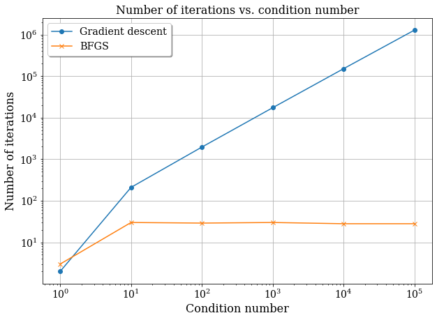

```python
iterations_GD = []
iterations_BFGS = []
for cond in conditon_set:
    result_GD = gradient_descent_elli_cond(x0, cond, alpha=1/cond)
    iterations_GD.append(result_GD[2])
    result_BFGS = optimize_f_elli_cond_bfgs(x0, cond)
    iterations_BFGS.append(result_BFGS[2])

plt.figure(figsize=(10, 7))
plt.plot(conditon_set, iterations_GD, 'o-')
plt.plot(conditon_set, iterations_BFGS, 'x-')
plt.xscale('log')
plt.yscale('log')
plt.xlabel('Condition number', size=16, fontfamily='serif')
plt.ylabel('Number of iterations', size=16, fontfamily='serif')
plt.title('Number of iterations vs. condition number', size=16, fontfamily='serif')
plt.tick_params(axis='x', labelsize=14)
plt.tick_params(axis='y', labelsize=14)
plt.legend(['Gradient descent', 'BFGS'], shadow=True, fontsize='x-large')
plt.grid(True)
plt.show()
```

We can see that the number of iterations for gradient descent is increasing as the parameter cond increases. Almost increasing linearly after $\text{cond} \geq 10^1$. For the BFGS algorithm, the number of iterations is increasing as the parameter cond increases at the beginning (till $10^1$), then it comes to a stable value as the parameter cond increases to $10^5$.

**Question b**

Create a similar graph for GD and BFGS optimizing (3). Discuss the difference observed.

We have $$ \nabla f_{\text {rot-elli, cond }}(x)=R^T \nabla f_{\text {elli, cond }}(R x) $$ Since $R$ is the rotation matrix, we have $$ R^{T} = R^{-1} $$ Therefore, we can deduce that $$ \nabla f_{\text {rot-elli, cond }}(x)=R^T \nabla f_{\text {elli, cond }}(R x) = R^{-1} \nabla f_{\text {elli, cond }}(R x) $$

```python
def gradient_f_elli_cond_rot(x, cond, R):
    n = len(x)
    Rx = R(x)
    grad_f_elli = gradient_f_elli_cond(Rx, cond)
    return R(grad_f_elli, inverse=True)

def gradient_descent_elli_cond_rot(initial_x, cond, R, alpha, threshold=1e-10, max_iter=10000000):
    x = initial_x
    num_iter = 0
    ftab = []

    for num_iter in range(max_iter):
        grad = gradient_f_elli_cond_rot(x, cond, R)
        x_new = x - alpha * grad
        ftab.append(f_rot_elli_cond(x, cond, R))
        if np.linalg.norm(x_new - x) < threshold:
            break
        x = x_new

    return x, f_rot_elli_cond(x, cond, R), num_iter, ftab

def optimize_f_elli_cond_bfgs_rot(initial_x, cond, R, threshold=1e-10, max_iter=10000000):
    """Optimize the elliptical function using BFGS.

    Parameters:
    - initial_x: Starting point for the optimization.
    - cond: Condition number.

    Returns:
    - The optimized value of x and the function value at that point.
    """
    result = minimize(fun=f_rot_elli_cond, x0=initial_x, args=(cond, R), method='BFGS', jac=gradient_f_elli_cond_rot, options={'gtol': threshold, 'maxiter': max_iter})
    return result.x, result.fun, result.nit
```

```python
R = cma.transformations.Rotation()

result_GD_rot = gradient_descent_elli_cond_rot(x0, cond, R, alpha=1/cond)
result_BFGS_rot = optimize_f_elli_cond_bfgs_rot(x0, cond, R)
print('Gradient descent method with rotation, final x', result_GD_rot[0])
print('Gradient descent method with rotation, final objective value', result_GD_rot[1])
print('Number of iterations with rotation (GD):', result_GD_rot[2])
print('-' * 100)
print('BFGS method, final x with rotation', result_BFGS_rot[0])
print('BFGS method, final objective value with rotation', result_BFGS_rot[1])
print('Number of iterations (BFGS) with rotation:', result_BFGS_rot[2])
```

```
Gradient descent method with rotation, final x [-7.57679119e-07 -5.66911944e-07 -3.19483153e-06 -2.33216935e-06
 -9.52031633e-07  1.60854053e-06  5.50559096e-07  2.29756575e-06
  3.93277616e-06 -2.48199374e-06  7.22692590e-07 -1.07489787e-06
 -2.20825140e-06  2.17169972e-06  3.27808449e-06  1.37614469e-06
 -1.36397567e-06 -4.57254730e-06 -1.62873750e-06  1.85018380e-06]
Gradient descent method with rotation, final objective value 4.999934219511854e-11
Number of iterations with rotation (GD): 1160443
----------------------------------------------------------------------------------------------------
BFGS method, final x with rotation [ 1.01909401e-15  6.92479345e-16 -1.81395136e-16 -4.35743160e-16
 -9.46771624e-16 -2.36203296e-16 -3.96838016e-16 -8.29131768e-16
  1.46635620e-16  1.75095401e-16 -4.90617626e-16 -5.87288242e-17
  5.04662828e-16  1.33657130e-15 -6.34150932e-16 -8.27438822e-16
  7.99039432e-16 -9.81998220e-16 -5.22986172e-16 -8.06996562e-16]
BFGS method, final objective value with rotation 1.943883590946417e-29
Number of iterations (BFGS) with rotation: 31
```

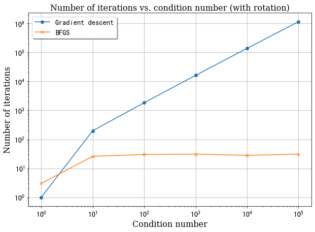

```python
iterations_GD_rot = []
iterations_BFGS_rot = []
for cond in conditon_set:
    result_GD_rot = gradient_descent_elli_cond_rot(x0, cond, R, alpha=1/cond)
    iterations_GD_rot.append(result_GD_rot[2])
    result_BFGS_rot = optimize_f_elli_cond_bfgs_rot(x0, cond, R)
    iterations_BFGS_rot.append(result_BFGS_rot[2])

plt.figure(figsize=(10, 7))
plt.plot(conditon_set, iterations_GD_rot, 'o-')
plt.plot(conditon_set, iterations_BFGS_rot, 'x-')
plt.xscale('log')
plt.yscale('log')
plt.xlabel('Condition number', size=16, fontfamily='serif')
plt.ylabel('Number of iterations', size=16, fontfamily='serif')
plt.title('Number of iterations vs. condition number (with rotation)', size=16, fontfamily='serif')
plt.tick_params(axis='x', labelsize=14)
plt.tick_params(axis='y', labelsize=14)
plt.legend(['Gradient descent', 'BFGS'], shadow=True, fontsize='x-large')
plt.grid(True)
plt.show()
```

### 2.4 Convergence graphs

**Question a**

Display some convergence graphs (i.e. function value on the $y$-axis and number of iterations on the $\mathrm{x}$-axis) of GD (with a well chosen step-size) and CD on the function (3) for cond $=10^3$. Explain how you chose the step-size for GD and detail the implementation of the gradient. You can consider $n=10$ and vary the initial vector $x_0$.

| Answer to Question a |
| --- |

- Gradient Descent with fixed step-size, here we choose $\alpha = 0.0005$.
- Gradient Descent with the Armijo method in line-search procedure.
- Gradient Descent with the Optimal step-size, here we choose $\alpha = \frac{1}{L} = \frac{1}{\text{cond}}=0.001$.
- Gradient Descent with the variable step-size.

1. **Algorithm GD with variable step**

   **Initialization**: Choose a starting point $x_0$, starting step $t=t_0$, maximum step $t_M, \eta_{+}>1, \eta_{-}<1$ and set $i=0$

   **Step $i$** :
   - compute $f\left(x_i\right)$ and $\nabla f\left(x_i\right)$
   - set a temporary new point $$ x_{\text {temp }}=x_i-t \nabla f\left(x_i\right) $$
   - **If $f\left(x_{i+1}\right)<f\left(x_i\right)$**
     - Accept the iteration: $x_{i+1}=x_{\text {temp }}$
     - increase the step size: $t=\min \left\{t \cdot \eta_{+}, t_M\right\}$
   - **Else**
     - Refuse the iteration
     - decrease the step size: $t=t \cdot \eta_{-}$
   - **check convergence (additionally you may check if $t$ is too small)**
2. **Algorithm GD with Armijo line-search**

   **Initialization:** Choose a starting point $x_0$, an initial step $t=t_0, \eta>1$, $m_1 \in(0,0.5)$ and set $i=0$

   **Step $i$** :
   - compute $f\left(x_i\right)$ and $\nabla f\left(x_i\right)$
   - **line-search:** $q(t)=f\left(x_i-t \nabla f\left(x_i\right)\right)$, set $t=t_0$
   - **while:** $m_1 q^{\prime}(0)<(q(t)-q(0)) / t$ **do** $t \leftarrow t / \eta$
   - set

   $$ x_{i+1}=x_i-t \nabla f\left(x_i\right) $$

Plot of the convergence rate of the function $f_{\text {rot-elli, cond }}(x)$ with different initial point $x_0$ is presented below. Also the code of the algorithms.

```python
def gradientVariableStep(f, df, x_init, cond=cond, R=R, step=0.1, tol=1e-06, maxiter=200):
    # initialization
    maxstep = 10
    x = x_init.copy()
    xtab = []
    ftab = []
    xtab.append(x)  # add x to the list xtab
    pval = f(x, cond, R)
    ftab.append(pval)
    it = 0  # iteration count
    g = df(x, cond, R)
    while ((it == 0) or (step > tol and it < maxiter and np.linalg.norm(xtab[-1]-xtab[-2])) > tol):
        # linesearch... this gives you the step
        actx = x-step*g
        val = f(actx, cond, R)
        if (val < pval):
            # accept iteration
            x = actx
            pval = val
            step = min(1.1*step, maxstep)
            xtab.append(x)
            ftab.append(val)
            g = df(x, cond, R)
            it = it+1
        else:
            # refuse iteration
            step = 0.8*step

    # boolean to indicate the convergence
    if (it == maxiter):
        conv = False
    else:
        conv = True
    return xtab, ftab, conv

def gradientDescentArmijo(f, df, x_init, cond=cond, R=R, tau=0.5, c=0.1, maxiter=200, tol=1e-6):
    x = x_init.copy()
    xtab = []
    ftab = []
    xtab.append(x)
    ftab.append(f(x, cond, R))
    it = 0
    while ((it == 0)
           or (it < maxiter and np.linalg.norm(xtab[-1] - xtab[-2])) > tol):
        it += 1
        g = df(x, cond, R)
        t = 1.0
        while f(x - t * g, cond, R)  > f(x, cond, R) - c * t * np.dot(g, g):
            t = tau * t
        x = x - t * g
        xtab.append(x)
        ftab.append(f(x, cond, R))
    if (it == maxiter):
        conv = False
    else:
        conv = True
    return xtab, ftab, conv

def gradient_descent_optimal(initial_x, cond, R, alpha, threshold=1e-10, max_iter=10000000):
    x = initial_x
    num_iter = 0
    ftab = []

    for num_iter in range(max_iter):
        grad = gradient_f_elli_cond_rot(x, cond, R)
        x_new = x - alpha * grad
        ftab.append(f_rot_elli_cond(x_new, cond, R))
        if np.linalg.norm(x_new - x) < threshold:
            break
        x = x_new

    return x, f_rot_elli_cond(x, cond, R), num_iter, ftab
```

```python
# Test of the algorithm
n = 10  # Dimension of the problem
cond = 1000
R = cma.transformations.Rotation()
x0_1 = np.random.uniform(0, 10, n)
x0_2 = np.random.uniform(0, 30, n)
x0_3 = np.random.uniform(0, 100, n)
ftab_variable_initial_1 = gradientVariableStep(f_rot_elli_cond, gradient_f_elli_cond_rot, x0_1, cond=cond, step=0.1, tol=1e-10, maxiter=1e7)[1]
ftab_Armijo_initial_1 = gradientDescentArmijo(f_rot_elli_cond, gradient_f_elli_cond_rot, x0_1, cond=cond, R=R, tau=0.5, c=0.1, maxiter=1e7, tol=1e-10)[1]
ftab_optimal_initial_1 = gradient_descent_optimal(x0_1, cond, R, alpha=1/cond)[3]
ftab_fixed_initial_1 = gradient_descent_elli_cond_rot(x0_1, cond, R, alpha=0.0005)[3]
ftab_variable_initial_2 = gradientVariableStep(f_rot_elli_cond, gradient_f_elli_cond_rot, x0_2, cond=cond, step=0.1, tol=1e-10, maxiter=1e7)[1]
ftab_Armijo_initial_2 = gradientDescentArmijo(f_rot_elli_cond, gradient_f_elli_cond_rot, x0_2, cond=cond, R=R, tau=0.5, c=0.1, maxiter=1e7, tol=1e-10)[1]
ftab_optimal_initial_2 = gradient_descent_optimal(x0_2, cond, R, alpha=1/cond)[3]
ftab_fixed_initial_2 = gradient_descent_elli_cond_rot(x0_2, cond, R, alpha=0.0005)[3]
ftab_variable_initial_3 = gradientVariableStep(f_rot_elli_cond, gradient_f_elli_cond_rot, x0_3, cond=cond, step=0.1, tol=1e-10, maxiter=1e7)[1]
ftab_Armijo_initial_3 = gradientDescentArmijo(f_rot_elli_cond, gradient_f_elli_cond_rot, x0_3, cond=cond, R=R, tau=0.5, c=0.1, maxiter=1e7, tol=1e-10)[1]
ftab_optimal_initial_3 = gradient_descent_optimal(x0_3, cond, R, alpha=1/cond)[3]
ftab_fixed_initial_3 = gradient_descent_elli_cond_rot(x0_3, cond, R, alpha=0.0005)[3]
```

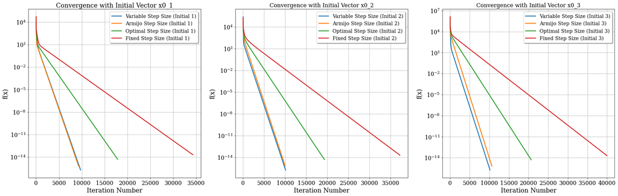

```python
# Plot of the convergence with the optimal step and the variable step, plot with subgraph
# Ensure Unicode minus sign issue is fixed
import matplotlib.font_manager as font_manager
plt.rcParams['font.family'] = 'serif'

fig, axs = plt.subplots(1, 3, figsize=(25, 8))

# Plot for initial vector x0_1
axs[0].plot(ftab_variable_initial_1, label='Variable Step Size (Initial 1)', linewidth=2.5)
axs[0].plot(ftab_Armijo_initial_1, label='Armijo Step Size (Initial 1)', linewidth=2.5)
axs[0].plot(ftab_optimal_initial_1, label='Optimal Step Size (Initial 1)', linewidth=2.5)
axs[0].plot(ftab_fixed_initial_1, label='Fixed Step Size (Initial 1)', linewidth=2.5)
axs[0].set_title('Convergence with Initial Vector x0_1', size=18)
axs[0].set_xlabel('Iteration Number', size=18)
axs[0].set_ylabel('f(x)', size=18)
axs[0].set_yscale('log')  # Corrected method call
axs[0].tick_params(labelsize=16)
axs[0].grid(True)
axs[0].legend(shadow=True, fontsize='x-large')

# Plot for initial vector x0_2
axs[1].plot(ftab_variable_initial_2, label='Variable Step Size (Initial 2)', linewidth=2.5)
axs[1].plot(ftab_Armijo_initial_2, label='Armijo Step Size (Initial 2)', linewidth=2.5)
axs[1].plot(ftab_optimal_initial_2, label='Optimal Step Size (Initial 2)', linewidth=2.5)
axs[1].plot(ftab_fixed_initial_2, label='Fixed Step Size (Initial 2)', linewidth=2.5)
axs[1].set_title('Convergence with Initial Vector x0_2', size=16)
axs[1].set_xlabel('Iteration Number', size=18)
axs[1].set_ylabel('f(x)', size=18)
axs[1].set_yscale('log')  # Corrected method call
axs[1].tick_params(labelsize=16)
axs[1].grid(True)
axs[1].legend(shadow=True, fontsize='x-large')

axs[2].plot(ftab_variable_initial_3, label='Variable Step Size (Initial 3)', linewidth=2.5)
axs[2].plot(ftab_Armijo_initial_3, label='Armijo Step Size (Initial 3)', linewidth=2.5)
axs[2].plot(ftab_optimal_initial_3, label='Optimal Step Size (Initial 3)', linewidth=2.5)
axs[2].plot(ftab_fixed_initial_3, label='Fixed Step Size (Initial 3)', linewidth=2.5)
axs[2].set_title('Convergence with Initial Vector x0_3', size=16)
axs[2].set_xlabel('Iteration Number', size=18)
axs[2].set_ylabel('f(x)', size=18)
axs[2].set_yscale('log')  # Corrected method call
axs[2].tick_params(labelsize=16)
axs[2].grid(True)
axs[2].legend(shadow=True, fontsize='x-large')

# Display the plots
plt.tight_layout()
plt.show()
```

```python
ftab_CD_initial_1 = coordinate_descent(x0_1, cond, R, tol=1e-10, max_iter=1000000, rotate=True)[2]
ftab_CD_initial_2 = coordinate_descent(x0_2, cond, R, tol=1e-10, max_iter=1000000, rotate=True)[2]
ftab_CD_initial_3 = coordinate_descent(x0_3, cond, R, tol=1e-10, max_iter=1000000, rotate=True)[2]
```

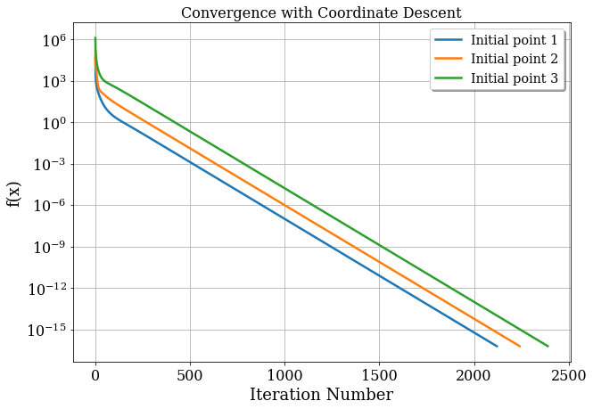

```python
figure = plt.figure(figsize=(10, 7))

plt.plot(ftab_CD_initial_1, label='Initial point 1', linewidth=2.5)
plt.plot(ftab_CD_initial_2, label='Initial point 2', linewidth=2.5)
plt.plot(ftab_CD_initial_3, label='Initial point 3', linewidth=2.5)
plt.title('Convergence with Coordinate Descent', size=16)
plt.xlabel('Iteration Number', size=18)
plt.ylabel('f(x)', size=18)
plt.yscale('log')  # Corrected method call
plt.tick_params(labelsize=16)
plt.grid(True)
plt.legend(shadow=True, fontsize='x-large')
plt.show()
```

**Question b**

Describe the results you obtain. Which type of convergence do you observe? Is it surprising? Comment on the impact of the initial vector.

| Answer to Question b |
| --- |

We set $n=10, \text{cond}=10^{3}, \text{stopping criterion}=10^{-10}, \text{max iteration}=10^{7}$. And we set the y-axis with log scale. The three initial points are choose in Uniform distribution as follows:

```
x0_1 = np.random.uniform(0, 10, n)
x0_2 = np.random.uniform(0, 30, n)
x0_3 = np.random.uniform(0, 100, n)
```

For the plot of **Gradient Descent**, we can see that the convergence rate is **linear**. The convergence rate of Armijo and variable step-size is faster than the fixed step-size. The GD with optimal step-size converge faster than the GD with $\alpha=0.0005$ which corresponds to our expectation. Also, we can see that the convergence rate is not affected by the initial point compared with the three subplots with different initial vector (The slope remain the same from the graph).

For the **Coordinate Descent** method, the convergence rate is also **linear**. And we can find that the convergence rate is not affected by the initial point.

**Question c [Bonus question: graded with extra points]**

Investigate the convergence of GD, CD, and BFGS on the Rosenbrock function (4) in dimension 10. Explain in details how you proceed, which tests you performed, which graphs you decide to display and comment on the difference observed, on the impact of the initial vector, of the step-size choice for GD. Beware that it is not obvious to make fair comparisons among algorithms as you cannot always compare two iterations of an algorithm if one algorithm uses the gradient and the other not. One way to solve this issue is to compare the number of calls to the objective function and assume a cost of $n$ function evaluations for one gradient call (this comes from the cost of evaluating the gradient numerically via finite differences where the cost is $n+1$).

#### Coordinate Descent of Rosenbrock Function

We have the Rosenbrock function: $$ f_{\text {rosen }}(x)=\sum_{i=1}^{n-1}\left[100 \cdot\left(x_{i+1}-x_i^2\right)^2+\left(1-x_i\right)^2\right] . $$ Assume we have the initial point $x_0=(x_1^{1}, x_1^{2},...,x_1^{n})$. Then we try to compute $$ \begin{aligned} x_{2}^{1} &= \underset{y \in \mathbb{R}}{\arg \min } f_{\text{rosen}}\left(y, x_1^{2}, \ldots, x_1^n\right) \\ &= \underset{y \in \mathbb{R}}{\arg \min } \left(100 (x_1^2-y)^2 + (1-y)^{2}\right) + \sum_{i=2}^{n-1}\left[100 \cdot\left(x_{i+1}-x_i^2\right)^2+\left(1-x_i\right)^2\right] \end{aligned} $$ Since the right-side part of the RHS is fixed, we can transform the problem into $$ \begin{aligned} x_{2}^{1} &= \underset{y \in \mathbb{R}}{\arg \min } \left(100 (x_1^2-y)^2 + (1-y)^{2}\right) \\ &= \underset{y \in \mathbb{R}}{\arg \min } \left(100 x_1^4 - 200 x_1^2 y + 100 y^2 + 1 - 2 y + y^2\right) \\ \end{aligned} $$ Then we assume that $g(y) = 100 x_1^4 - 200 x_1^2 y + 100 y^2 + 1 - 2 y + y^2$, we can compute the derivative of $g(y)$: $$ g^{\prime}(y) = -200 x_1^2 + 200 y - 2 + 2y = 0 \Rightarrow y = \frac{100x_{1}^{2}+1}{101} \Rightarrow x_{2}^{1} = \frac{100x_{1}^{2}+1}{101} $$ With the same method, we can deduce that $$ x_{2}^{n} = x_{2}^{n-1} $$ Therefore, we can conclude that the formula of Coordinate Descent of Rosenbrock Function is: $$ \begin{cases} x_{k+1}^{j} = \frac{100x_{k}^{j+1}+1}{101} \quad \text{if } j \leq n-1 \\ x_{k+1}^{n} = x_{k}^{n} \quad \text{if } j = n \end{cases} $$

```python
N_dimension = 10
x0 = np.array([2] * N_dimension)

def Rosenbrock(x):
    return sum([100*(x[i+1]-x[i]**2)**2+(1-x[i])**2 for i in range(N_dimension-1)])


def GradRosenbrock(x):
    return np.array([200*(x[i+1]-x[i]**2)*(-2*x[i])-2*(1-x[i]) for i in range(N_dimension-1)]+[200*(x[N_dimension-1]-x[N_dimension-2]**2)])


def gradientFixedStep(f, df, x_init, step=1e-03, tol=1e-06, maxiter=200):
    # initialization
    x = x_init.copy()
    xtab = []
    ftab = []
    xtab.append(x)  # add x to the list xtab
    ftab.append(f(x))
    it = 0  # iteration count
    while ((it == 0) or (it < maxiter and np.linalg.norm(xtab[-1]-xtab[-2])) > tol):
        it = it+1
        g = df(x)
        # line-search
        x = x-step*g
        xtab.append(x)
        ftab.append(f(x))
    # boolean to indicate the convergence
    if (it == maxiter):
        conv = False
    else:
        conv = True
    return xtab, ftab, conv


def coordinate_descent_Rosenbrock(f, x0, tol=1e-06, max_iter=200):
    x = x0.copy()
    num_iter = 0
    n = len(x)
    ftab = []
    for num_iter in range(max_iter):
        x_prev = x.copy()
        ftab.append(f(x))
        for i in range(n):
            # Define a one-dimensional function for the i-th coordinate
            def g(y):
                x_new = np.copy(x)
                x_new[i] = y
                return f(x_new)

            # Minimize along the i-th coordinate
            res = minimize_scalar(g)
            x[i] = res.x

        # Check for convergence
        if np.linalg.norm(x - x_prev) < tol:
            break

    return x, num_iter, ftab


methods = ['GD', 'CD', 'CG', 'BFGS', 'Powell', 'L-BFGS-B']


def callbackF_sub(x):
    error = Rosenbrock(x)
    errors.append(error)
```

```python
result_all = []
for method in methods:
    errors = []
    if method == 'GD':
        result = gradientFixedStep(Rosenbrock, GradRosenbrock, x0, step=1e-05, tol=1e-10, maxiter=10**7)[1]
        result_all.append(result)
    elif method == 'CD':
        result = coordinate_descent_Rosenbrock(Rosenbrock, x0, tol=1e-10, max_iter=10**7)[2]
        result_all.append(result)
    else:
        result = scopt.minimize(Rosenbrock, x0, callback=callbackF_sub, method=method, tol=1e-10)
        result_all.append(errors)
```

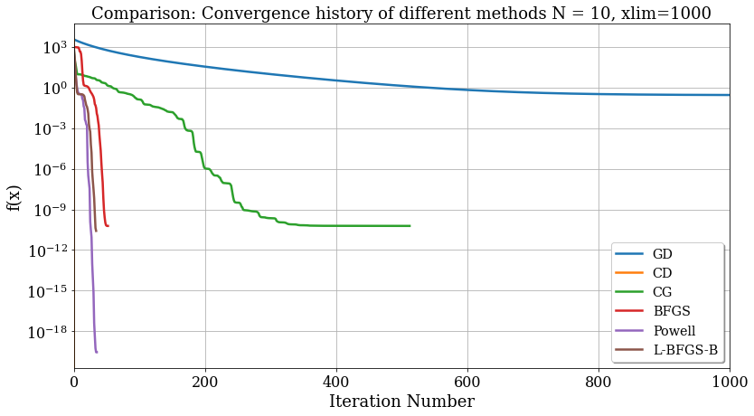

```python
plt.figure(figsize=(13, 7))
for i in range(len(methods)):
    plt.semilogy(result_all[i], label=methods[i], linewidth=2.5)
plt.legend()
plt.xlabel('Iteration')
plt.ylabel('Error (log scale)')
plt.xlim([0, 1000])
plt.yscale('log')  # Corrected method call
plt.xlabel('Iteration Number', size=18)
plt.ylabel('f(x)', size=18)
plt.title('Comparison: Convergence history of different methods N = 10, xlim=1000', size=18)
plt.tick_params(labelsize=16)
plt.grid(True)
plt.legend(shadow=True, fontsize='x-large', loc='lower right')
plt.show()
```

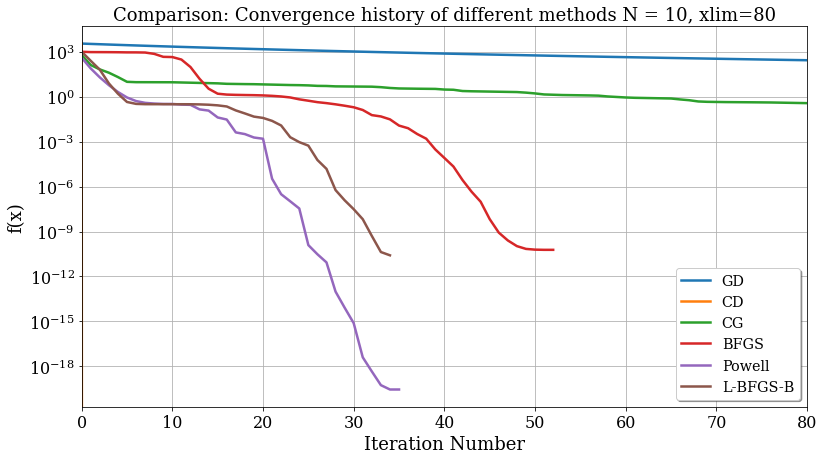

```python
plt.figure(figsize=(13, 7))
for i in range(len(methods)):
    plt.semilogy(result_all[i], label=methods[i], linewidth=2.5)
plt.legend()
plt.xlabel('Iteration')
plt.ylabel('Error (log scale)')
plt.xlim([0, 80])
plt.yscale('log')  # Corrected method call
plt.xlabel('Iteration Number', size=18)
plt.ylabel('f(x)', size=18)
plt.title('Comparison: Convergence history of different methods N = 10, xlim=80', size=18)
plt.tick_params(labelsize=16)
plt.grid(True)
plt.legend(shadow=True, fontsize='x-large', loc='lower right')
plt.show()
```